# Decrescenza dei posti letto del SSN dal 2010 al 2016

*Il data-set contiene i **posti letto** accreditati a carico del Servizio Sanitario Nazionale, presenti al primo gennaio dell’anno di riferimento in ciascuna struttura ospedaliera pubblica, equiparata o casa di cura privata accreditata.*

I dati utilizzati per l’elaborazione della presentazione sono stati rilevati attraverso il flusso informativo istituito con il decreto del Ministero della salute 11 giugno 2010 al sito http://www.dati.salute.gov.it/dati/elencoDataset.jsp?menu=dati&ord=aggiornamento&datasetAgg.page=5

### Campi e consistenza del dataset

**anno**: anno di riferimento  
**cod_regione**: codice regione  
**regione**  
**cod_az**: codice dell’Azienda Sanitaria  
**tipo_az**: Tipologia dell’Azienda Sanitaria  
*1 = Azienda sanitaria locale (ASL)*  
2 = Struttura sanitaria aziendale di tipo ospedaliero  
**cod_stru**: codice della struttura di ricovero ospedaliero  
**den_stru**: denominazione della struttura di ricovero ospedaliero  
**indirizzo**: indirizzo principale della struttura di ricovero ospedaliero  
**cod_com**: codice ISTAT del Comune in cui è ubicata la struttura di ricovero ospedaliero. Il codice ISTAT di 6 caratteri: i primi tre caratteri rappresentano il codice della provincia; gli ultimi tre caratteri identificano il codice del comune.  
**comune**: denominazione del Comune in cui è ubicata la struttura di ricovero ospedaliero  
**provincia**: sigla della provincia in cui è ubicata la struttura di ricovero  
**cod_tipo_stru** Codice della tipologia di struttura di ricovero ospedaliero.  
*0=Azienda Ospedaliera*  
1=Ospedale a gestione diretta  
*2.1=Azienda Ospedaliera universitaria integrata con il Servizio Sanitario Nazionale*  
2.2=Azienda Ospedaliera integrata con l’Universit?  
*2.3=Policlinico universitario privato*  
3.1=IRCCS pubblico  
*3.2=IRCCS privato*  
3.3=IRCCS fondazione  
*4=Ospedale classificato o assimilato ai sensi dell’art. 1, ultimo comma, della Legge 132/1968*  
5.1=Casa di cura privata accreditata  
*8=Istituto qualificato presidio della U.S.L.*  
9=Ente di ricerca  
**desc_tipo_stru** Descrizione della tipologia di struttura di ricovero ospedaliero  
**disciplina** Tipologia della disciplina ospedaliera o della specialit? clinica.  
*LUNGODEGENZA*  
RIABILITAZIONE posti letto afferenti alle discipline  
+Unità spinale  
+Recupero e riabilitazione funzionale  
+Neuro-riabilitazione  
*ACUTI posti letto afferenti a tutte le altre discipline non ricomprese in Lungodegenza e Riabilitazione.  
**ordinari**: posti letto attivi al 01 gennaio dell’anno di riferimento dedicati all’ttività di ricovero in regime ordinario e a pagamento.  
**day_hospital** posti letto attivi al 01 gennaio dell’anno di riferimento dedicati all’attivit? di ricovero in regime di day hospital (ricovero diurno di tipo medico).  
**day_surgery** posti letto attivi al 01 gennaio dell’anno di riferimento dedicati all’attivit? di ricovero in regime di day surgery (ricovero diurno di tipo chirurgico).  
**totali** somma dei posti letto ordinari, day hospital e day surgery.

```r
#librerie
library(readr)
library(dplyr)
library(ggplot2)
library(tidyverse)
library(modelr)
library(broom)
```

Le informazioni contenute nel data-set sono elaborate in riferimento ai dati che le Regioni trasmettono al Ministero della salute, attraverso i modelli di rilevazione HSP12 e HSP13, ai sensi del decreto del Ministro della salute 5 dicembre 2006.  
Qualora per una determinata struttura non risultino trasmessi i modelli di rilevazione HSP12/HSP13, i seguenti campi contengono il valore convenzionale N.D.: TIPO DI DISCIPLINA, POSTI LETTO ORDINARI, POSTI LETTO DAY HOSPITAL, POSTI LETTO DAY SURGERY, TOTALE POSTI LETTO.

**Le righe con dati sul numero posti letto non noti**

```
## # A tibble: 3 x 5
##   anno  comune den_stru                    cod_tipo_stru totali
##   <fct> <chr>  <chr>                       <fct>          <int>
## 1 2010  ROMA   OSPEDALE ISRAELITICO        4                 NA
## 2 2010  ROMA   CASA DI CURA VILLA PIA      51                NA
## 3 2010  ROMA   CASA DI CURA CITTA` DI ROMA 51                NA
```

Le tre righe contenenti valori non noti non saranno considerate nell’analisi.

## Quanto e come stanno decrescendo i posti letto del SSN?

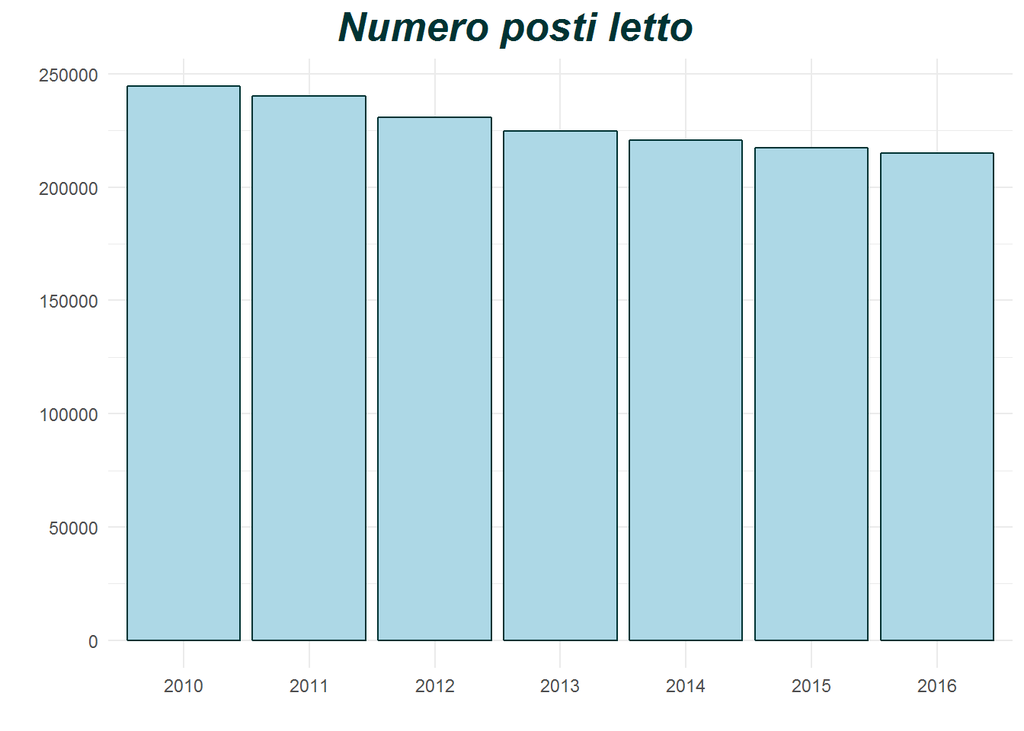

*Percentuali di decrescenza*

```
## # A tibble: 7 x 3
##   anno  totali percentuale_decrescenza
##   <fct>  <int>                   <dbl>
## 1 2010  244510                    0.
## 2 2011  240235                    1.75
## 3 2012  230594                    5.69
## 4 2013  224595                    8.14
## 5 2014  220774                    9.71
## 6 2015  217376                   11.1
## 7 2016  215064                   12.0
```

Il numero dei posti letto in Italia decresce di anno in anno. Dal primo gennaio 2010 al primo gennaio 2016 il numero dei posti letto ? diminuito del 12%, ovvero di 29.446 posti letto.

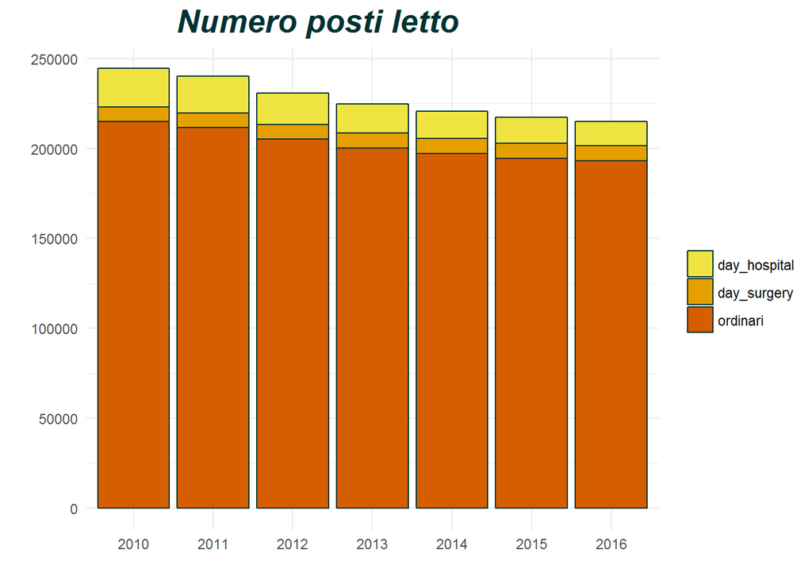

*Percentuali di posti letto ordinari, day hospital e day surgery*

```
## # A tibble: 7 x 4
##   anno  perc_ordinari perc_hospitali perc_surgery
##   <fct>         <dbl>          <dbl>        <dbl>
## 1 2010          0.879         0.0878       0.0329
## 2 2011          0.881         0.0854       0.0340
## 3 2012          0.889         0.0752       0.0356
## 4 2013          0.892         0.0717       0.0367
## 5 2014          0.894         0.0696       0.0368
## 6 2015          0.895         0.0670       0.0383
## 7 2016          0.897         0.0637       0.0388
```

Dal grafico possiamo notare che la grande maggioranza (più dell’80%) di posti letto è di tipo “ordinari”. Meno del 9% si aggiudica ai posti letto relativi al “day hospital”, mentre per il “day surgery” la percentuale è minore del 4%.

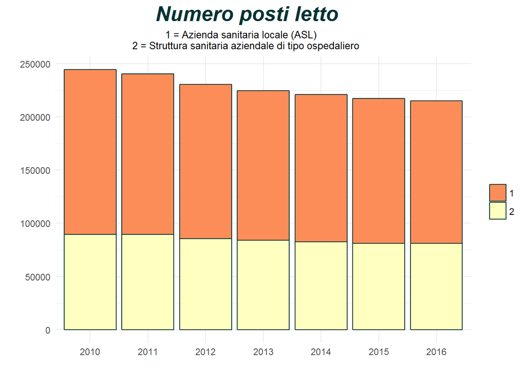

Dal grafico possiamo evincere che la decrescenza dei posti letto è dovuta soprattutto alla decrescenza dei posti letto relativi alle ASL (Aziende sanitarie locali).

*Decrescenza dei posti letto delle ASL*

```
## # A tibble: 7 x 3
## # Groups:   anno [7]
##   anno  totali decrescenza_ASL
##   <fct>  <int>           <dbl>
## 1 2010  155093            0.
## 2 2011  150920            2.69
## 3 2012  145026            6.49
## 4 2013  140776            9.23
## 5 2014  138119           10.9
## 6 2015  136446           12.0
## 7 2016  134187           13.5
```

*Decrescenza dei posti letto delle strutture sanitatie aziendali di tipo ospedaliero*

```
## # A tibble: 7 x 3
## # Groups:   anno [7]
##   anno  totali decrescenza_SSA
##   <fct>  <int>           <dbl>
## 1 2010   89417           0.
## 2 2011   89315           0.114
## 3 2012   85568           4.30
## 4 2013   83819           6.26
## 5 2014   82655           7.56
## 6 2015   80930           9.49
## 7 2016   80877           9.55
```

Dal 2010 al 2016 il numero posti letto ASL è diminuito più del 13%, precisamente di 20.906 posti letto. Mentre la diminuzione del numero posti letto relativi alle strutture sanitarie aziendali è meno incisiva, pari a 8.540 posti letto che corrisponde a meno del 10%.

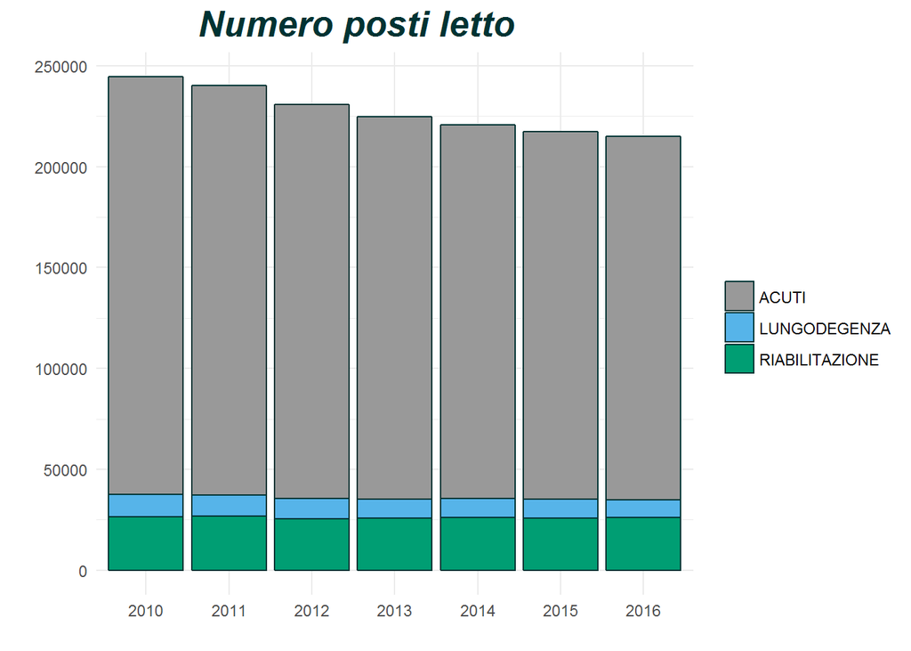

*Decrescenza relativa agli ACUTI, LUNGODEGENZA, RIABILITAZIONE*

```
## # A tibble: 6 x 3
## # Groups:   anno [2]
##   anno  disciplina     totali
##   <fct> <fct>           <int>
## 1 2010  ACUTI          207066
## 2 2016  ACUTI          180161
## 3 2010  LUNGODEGENZA    10890
## 4 2016  LUNGODEGENZA     8773
## 5 2010  RIABILITAZIONE  26554
## 6 2016  RIABILITAZIONE  26130
```

## L’andamento nelle singole regioni

Il decreto sulla revisione della spesa (spending review) del 2012 ha previsto che nel bienio 2013-2015 si dovesse passare a un rapporto di 3,7 posti letto ogni mille abitanti, ovvero ad un taglio di trentamila letti negli ospedali italiani. Entro dicembre dell’anno 2012 le regioni dovevano indicare come effettuare la riduzione.

> Com’è stata applicata la riduzione forzata dei posti letto nelle regioni?

Il numero dei residenti nelle regioni è molto differente, quindi per poter analizzare e confrontare il numero dei posti letto nelle varie regioni considereremo il numero posti letto pro capite. Per determinare la corrispondenza tra abitanti e regione, prenderemo in considerazione il dataset presente al sito del Ministero della Salute “Dataset Corrispondenze ASL-Comuni e popolazione residente” con dati relativi all’anno 2016.

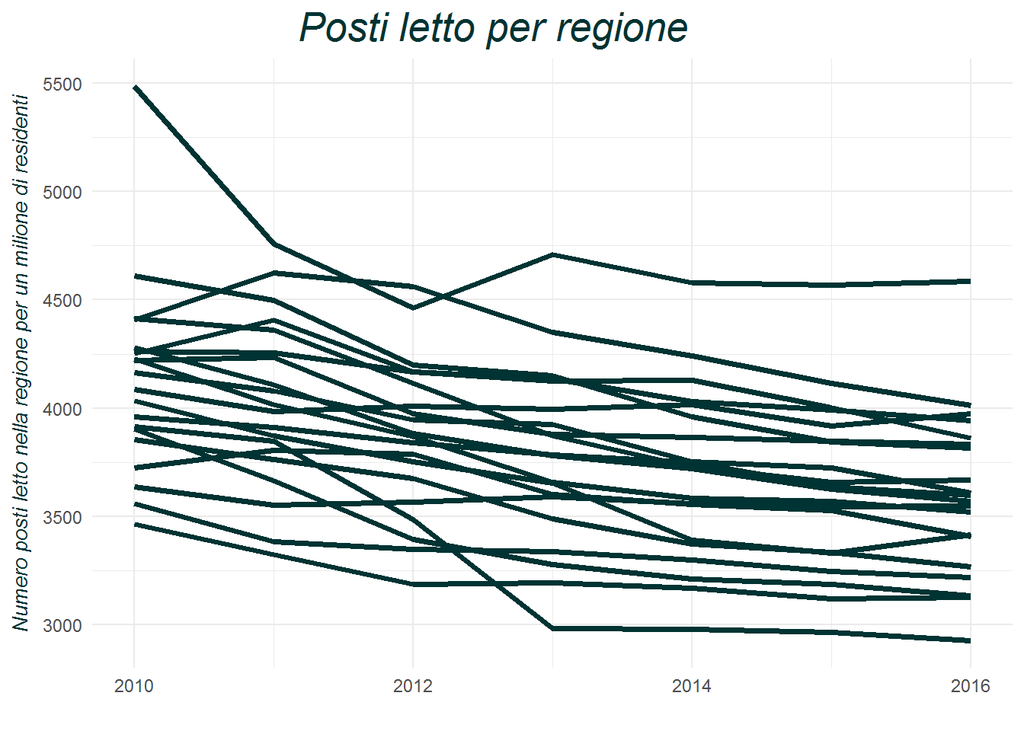

Mentre in Italia dal 2010 al 2016 i posti letto decrescono di anno in anno, andando a guardare alle singole regioni, l’andamento non è sempre decrescente. Di seguito faremo una analisi più approfondita.

## Ci sono differenze tra Nord e Centro-Sud?

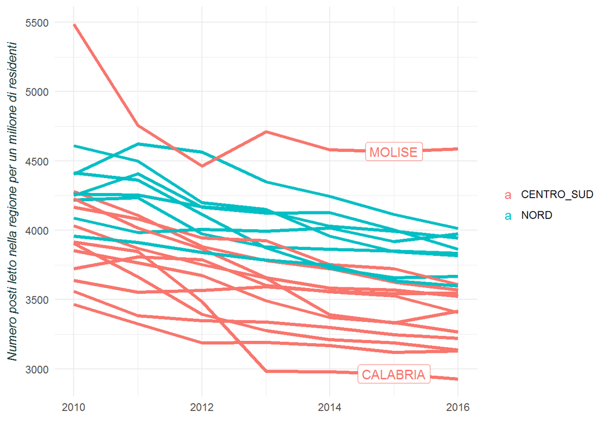

*Differenza tra Molise e Calabria*

```
## # A tibble: 2 x 4
## # Groups:   anno, cod_regione [2]
##    anno regione  cod_regione posti_su_milione
##   <int> <chr>    <chr>                  <dbl>
## 1  2016 MOLISE   140                    4587.
## 2  2016 CALABRIA 180                    2928.
```

Ad eccezione della regione Molise tutte le altre regioni del centro-sud dispongono di meno posti letto pro capite in confronto alle regioni del nord. Al 01.01.2016 la regione Molise dispone del numero massimo di posti letto pro capite, mentre la regione Calabria dispone del numero minimo di posti letto pro capite. La differenza di posti letto su mille residenti è di 1,66, quindi la Calabria ha in proporzione 36% posti letto pro capite in meno del Molise.

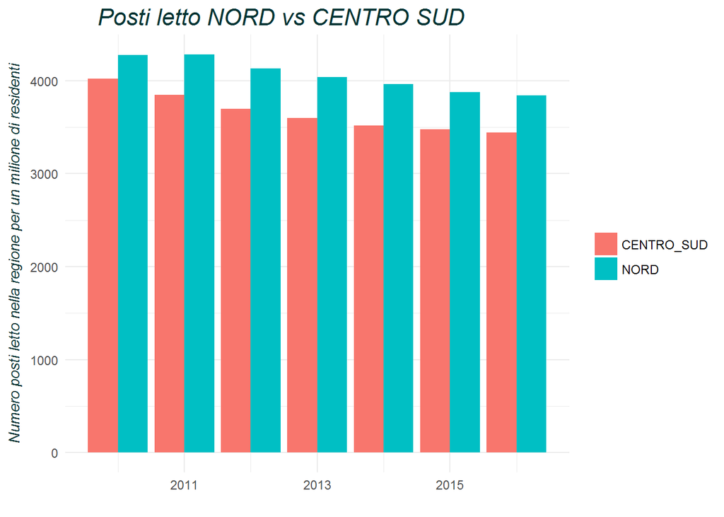

In tutti gli anni al nord il numero dei posti letto pro capite è maggiore del numero posti letto pro capite nel centro sud. Possiamo accomunare il Nord e il Centro-Sud solo per l’andamento del numero dei posti letto, che in entrambi i casi è sempre decrescente in media.

*Differenza tra nord e centro-sud*

```
## # A tibble: 4 x 3
## # Groups:   anno [2]
##    anno macro_area posti_su_milione
##   <int> <fct>                 <dbl>
## 1  2010 CENTRO_SUD            4021.
## 2  2016 CENTRO_SUD            3445.
## 3  2010 NORD                  4276.
## 4  2016 NORD                  3839.
```

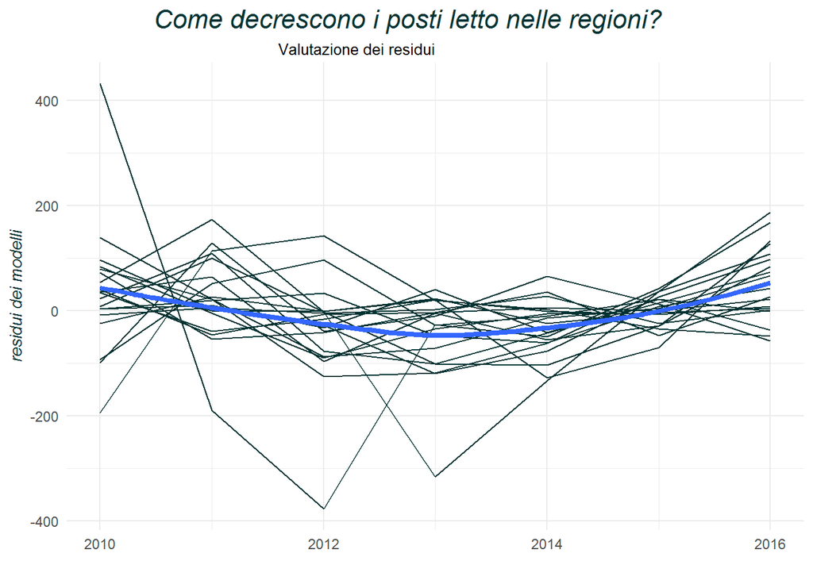

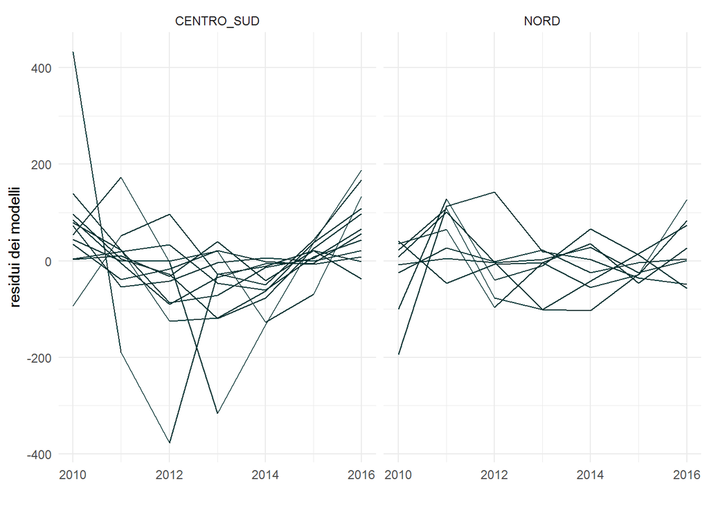

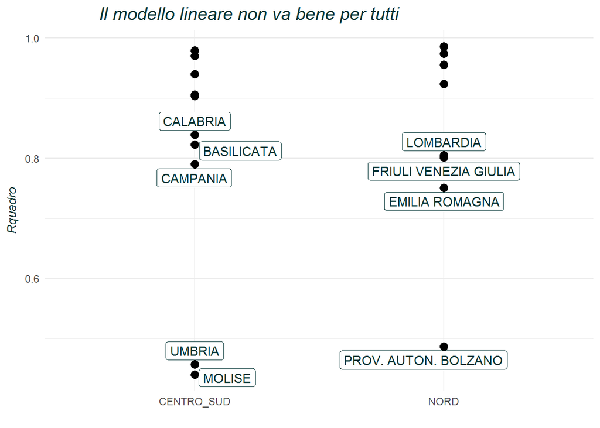

Nelle regioni Umbria, Molise e nella provincia autonoma di Bolzano, la variabilità spiegata dal modello lineare è minore del 50%. Mente per Calabria, Basilicata, Campania, Lombardia, Friuli Venezia Giulia e Emilia Romagna l’R^2 è maggiore del 70%, ma minore dell’85%.

*Indicatori della bontà dei modelli*

```
## # A tibble: 10 x 14
##    regione  cod_regione macro_area r.squared adj.r.squared sigma statistic
##    <chr>    <chr>       <fct>          <dbl>         <dbl> <dbl>     <dbl>
##  1 MOLISE   140         CENTRO_SUD     0.440         0.328 282.       3.93
##  2 UMBRIA   100         CENTRO_SUD     0.457         0.349  26.7      4.21
##  3 PROV. A~ 041         NORD           0.487         0.384  40.0      4.75
##  4 EMILIA ~ 080         NORD           0.751         0.701 122.      15.1
##  5 CAMPANIA 150         CENTRO_SUD     0.790         0.748  62.6     18.8
##  6 FRIULI ~ 060         NORD           0.802         0.762  84.6     20.2
##  7 LOMBARD~ 030         NORD           0.805         0.766  84.7     20.6
##  8 BASILIC~ 170         CENTRO_SUD     0.823         0.788  68.3     23.2
##  9 CALABRIA 180         CENTRO_SUD     0.839         0.807 194.      26.1
## 10 SICILIA  190         CENTRO_SUD     0.860         0.832  45.8     30.6
## # ... with 7 more variables: p.value <dbl>, df <int>, logLik <dbl>,
## #   AIC <dbl>, BIC <dbl>, deviance <dbl>, df.residual <int>
```

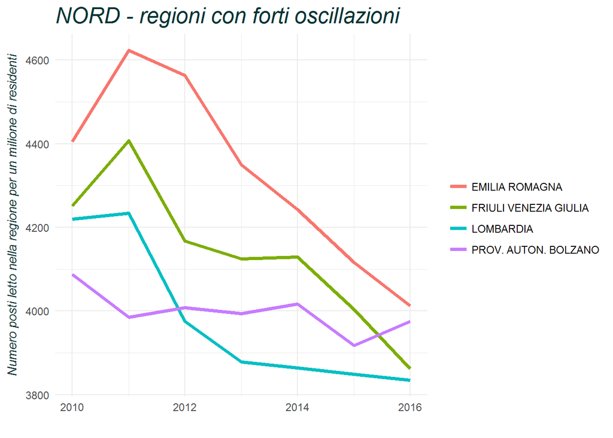

L’andamento nelle regioni Emilia Romagna, Friuli Venezia Giulia e Lombardia ? molto simile. Dalla crescita registrata nel 2010, si passa ad una forte decrescita a partire dal 2011 che non è intenta a frenare, ma prosegue fino al 01.01.2016.

```
## # A tibble: 6 x 4
## # Groups:   anno, cod_regione [6]
##    anno regione               cod_regione posti_su_milione
##   <int> <chr>                 <chr>                  <dbl>
## 1  2011 EMILIA ROMAGNA        080                    4623.
## 2  2016 EMILIA ROMAGNA        080                    4012.
## 3  2011 FRIULI VENEZIA GIULIA 060                    4407.
## 4  2016 FRIULI VENEZIA GIULIA 060                    3862.
## 5  2011 LOMBARDIA             030                    4234.
## 6  2016 LOMBARDIA             030                    3835.
```

In cinque anno, dal 2011 al 2016 il numero posti letto per mille residenti è diminuito di 0,6 in Emilia Romagna; 0,5 in Friuli Venezia Giulia e 0,4 in Lombardia.

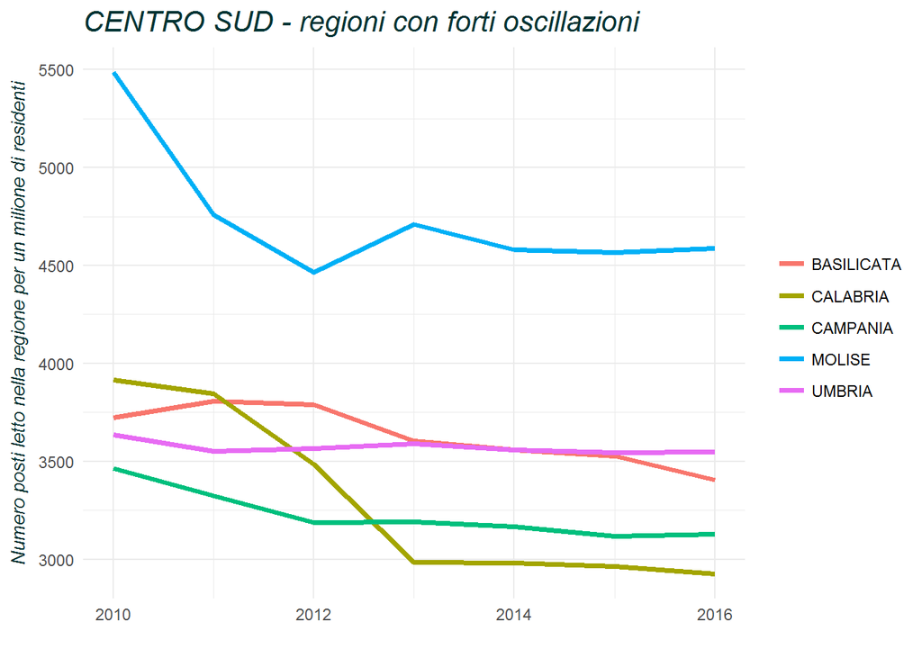

Come già visto in precedenza, il Molise è la regione che si discosta dalle altre per il maggiore numero dei posti letto. La regione però presenta differenze anche per quanto rigurda l’andamento: dalla decrescita segnalata fino al 01/01/2012, si passa alla crescita fino al 01.01.2013 e poi alla stabilizzazione. Da segnalare poi è anche la Calabria che dal 01.01.2013 ? l’unica regione in Italia che va sotto la soglia di 3 posti letto per mille residenti.

Mentre il numero dei posti letto in Italia decresce di anno in anno.

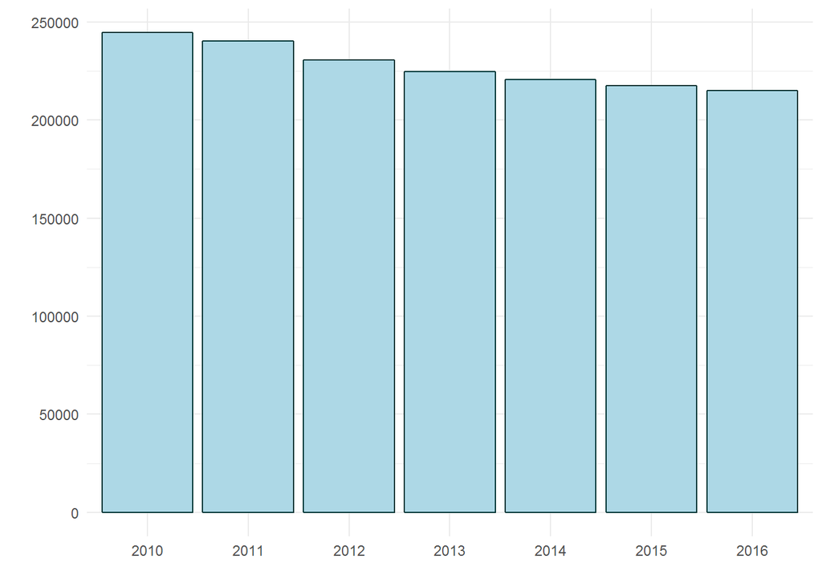

Se guardiamo in dettaglio alle singole regioni, certe presentano forti oscillazioni e andamento opposto.

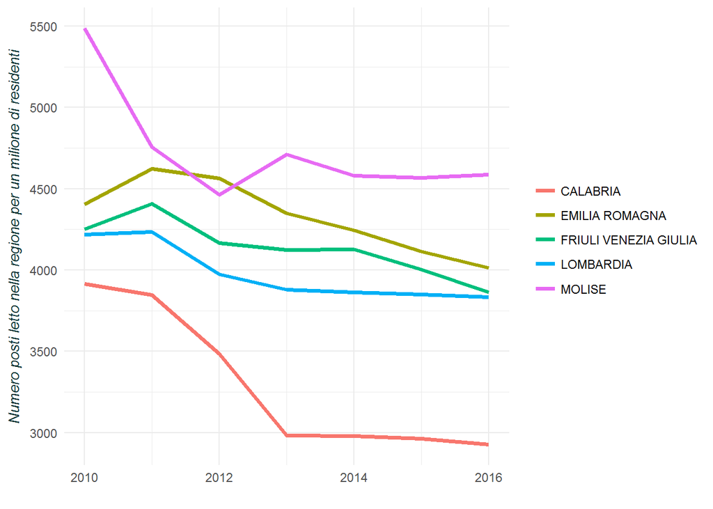

Non sempre i posti letto delle regioni diminuiscono. I casi più eclatanti di questo fenomeno sono le tre regioni del nord (FVG, Emilia Romagna e Lombardia) e la regione Molise, del centro sud. Ma l’andamento negli anni tra le regioni del nord e la regione MOlise è praticamente opposto: quando i primi crescono, Molise decresce e viceversa. Mentre la particolarità della regione Calabria è¨relativa alla forte decrescita dei posti letto in soli due anni, tra il 01.01.2011 e il 01.01.2013.